# Coursework 3: RNNs

#### Instructions

Please submit on CATe a zip file named *CW3_RNNs.zip* containing a version of this notebook with your answers. Write your answers in the cells below for each question.

## Recurrent models coursework

This coursework is separated into a coding and a theory component.

For the first part, you will use the Google Speech Commands v0.02 subset that you used in the RNN tutorial: http://www.doc.ic.ac.uk/~pam213/co460_files/

### Part 1 - Coding

In this part you will have to:

- Implement an LSTM
- Implement a GRU

### Part 2 - Theory

Here you will answer some theoretical questions about RNNs -- no detailed proofs and no programming.

### Part 1: Coding

### Dataset

We will be using the Google [*Speech Commands*](https://www.tensorflow.org/tutorials/sequences/audio_recognition) v0.02 [1] dataset.

[1] Warden, P. (2018). [Speech commands: A dataset for limited-vocabulary speech recognition](https://arxiv.org/abs/1804.03209). *arXiv preprint arXiv:1804.03209.*

```python
## MAKE SURE THIS POINTS INSIDE THE DATASET FOLDER.
dataset_folder = "./" # this should change depending on where you have stored the data files
```

### Initial code before coursework questions start:

```python
import math
import os
import random
from collections import defaultdict

import torch
import torch.nn as nn
from torch.autograd import Variable
from torch.utils.data import Dataset
import numpy as np
from scipy.io.wavfile import read
import librosa
from matplotlib import pyplot as plt

cuda = True if torch.cuda.is_available() else False

Tensor = torch.cuda.FloatTensor if cuda else torch.FloatTensor
```

```python
def set_seed(seed_value):
    """Set seed for reproducibility.
    """
    random.seed(seed_value)
    np.random.seed(seed_value)
    torch.manual_seed(seed_value)
    torch.cuda.manual_seed_all(seed_value)

set_seed(42)
```

```python
class SpeechCommandsDataset(Dataset):
    """Google Speech Commands dataset."""

    def __init__(self, root_dir, split):
        """
        Args:
            root_dir (string): Directory with all the data files.
            split    (string): In ["train", "valid", "test"].
        """
        self.root_dir = root_dir
        self.split = split

        self.number_of_classes = len(self.get_classes())

        self.class_to_file = defaultdict(list)

        self.valid_filenames = self.get_valid_filenames()
        self.test_filenames = self.get_test_filenames()

        for c in self.get_classes():
            file_name_list = sorted(os.listdir(self.root_dir + "data_speech_commands_v0.02/" + c))
            for filename in file_name_list:
                if split == "train":
                    if (filename not in self.valid_filenames[c]) and (filename not in self.test_filenames[c]):
                        self.class_to_file[c].append(filename)
                elif split == "valid":
                    if filename in self.valid_filenames[c]:
                        self.class_to_file[c].append(filename)
                elif split == "test":
                    if filename in self.test_filenames[c]:
                        self.class_to_file[c].append(filename)
                else:
                    raise ValueError("Invalid split name.")

        self.filepath_list = list()
        self.label_list = list()
        for cc, c in enumerate(self.get_classes()):
            f_extension = sorted(list(self.class_to_file[c]))
            l_extension = [cc for i in f_extension]
            f_extension = [self.root_dir + "data_speech_commands_v0.02/" + c + "/" + filename for filename in f_extension]
            self.filepath_list.extend(f_extension)
            self.label_list.extend(l_extension)
        self.number_of_samples = len(self.filepath_list)

    def __len__(self):
        return self.number_of_samples

    def __getitem__(self, idx):
        sample = np.zeros((16000, ), dtype=np.float32)

        sample_file = self.filepath_list[idx]

        sample_from_file = read(sample_file)[1]
        sample[:sample_from_file.size] = sample_from_file
        sample = sample.reshape((16000, ))

        sample = librosa.feature.mfcc(y=sample, sr=16000, hop_length=512, n_fft=2048).transpose().astype(np.float32)

        label = self.label_list[idx]

        return sample, label

    def get_classes(self):
        return ['one', 'two', 'three']

    def get_valid_filenames(self):
        class_names = self.get_classes()

        class_to_filename = defaultdict(set)
        with open(self.root_dir + "data_speech_commands_v0.02/validation_list.txt", "r") as fp:
            for line in fp:
                clean_line = line.strip().split("/")

                if clean_line[0] in class_names:
                    class_to_filename[clean_line[0]].add(clean_line[1])

        return class_to_filename

    def get_test_filenames(self):
        class_names = self.get_classes()

        class_to_filename = defaultdict(set)
        with open(self.root_dir + "data_speech_commands_v0.02/testing_list.txt", "r") as fp:
            for line in fp:
                clean_line = line.strip().split("/")

                if clean_line[0] in class_names:
                    class_to_filename[clean_line[0]].add(clean_line[1])

        return class_to_filename
```

```python
train_dataset = SpeechCommandsDataset(dataset_folder,
                                      "train")
valid_dataset = SpeechCommandsDataset(dataset_folder,
                                      "valid")

test_dataset = SpeechCommandsDataset(dataset_folder,
                                     "test")

batch_size = 100


num_epochs = 5
valid_every_n_steps = 20
train_loader = torch.utils.data.DataLoader(dataset=train_dataset,
                                           batch_size=batch_size,
                                           shuffle=True)
valid_loader = torch.utils.data.DataLoader(dataset=valid_dataset,
                                           batch_size=batch_size,
                                           shuffle=False)

test_loader = torch.utils.data.DataLoader(dataset=test_dataset,
                                          batch_size=batch_size,
                                          shuffle=False)
```

```python
for elt in train_loader:
    print(elt[0].size())
    break
```

```
torch.Size([100, 32, 20])
```

```python
# Size of the datasets
print(f"Size of train dataset: {len(train_dataset)}")
print(f"Size of valid dataset: {len(valid_dataset)}")
print(f"Size of test dataset: {len(test_dataset)}")
```

```
Size of train dataset: 9217
Size of valid dataset: 1052
Size of test dataset: 1228
```

### Question 1: Finalise the LSTM and GRU cells by completing the missing code

You are allowed to use nn.Linear.

```python
class LSTMCell(nn.Module):
    def __init__(self, input_size, hidden_size, bias=True):
        super(LSTMCell, self).__init__()
        self.input_size = input_size
        self.hidden_size = hidden_size
        self.bias = bias

        ########################################################################
        ## START OF YOUR CODE - Question 1a) Complete the missing code
        ########################################################################

        self.x2h = nn.Linear(input_size, 4*hidden_size, bias=self.bias) # 4*hidden_size because 4 different W : one forgetting gate, one output gate, and two input gates
        self.h2h = nn.Linear(hidden_size, 4*hidden_size, bias=self.bias)

        ########################################################################
        ## END OF YOUR CODE
        ########################################################################
        self.reset_parameters()

    def reset_parameters(self):
        std = 1.0 / math.sqrt(self.hidden_size)
        for w in self.parameters():
            w.data.uniform_(-std, std)

    def forward(self, input, hx=None):
        if hx is None:
            hx = input.new_zeros(input.size(0), self.hidden_size, requires_grad=False)
            hx = (hx, hx)

        # We used hx to pack both the hidden and cell states
        hx, cx = hx

        ########################################################################
        ## START OF YOUR CODE - Question 1b) Complete the missing code
        ########################################################################
        # The bias comes from both terms
        weighted_output = self.h2h(hx) + self.x2h(input)
        input_gate, forget_gate, output_gate, cell_state = weighted_output.chunk(4, 1)
        #Input gate
        iy = nn.functional.sigmoid(input_gate)
        #Forget gate
        fy = nn.functional.sigmoid(forget_gate)
        #Output gate
        oy = nn.functional.sigmoid(output_gate)
        #Cell state update
        cy_tilde = nn.functional.tanh(cell_state)

        cy = torch.mul(fy, cx) + torch.mul(iy, cy_tilde)
        hy = torch.mul(oy, nn.functional.tanh(cy))

        ########################################################################
        ## END OF YOUR CODE
        ########################################################################

        return (hy, cy)

class BasicRNNCell(nn.Module):
    def __init__(self, input_size, hidden_size, bias=True, nonlinearity="tanh"):
        super(BasicRNNCell, self).__init__()
        self.input_size = input_size
        self.hidden_size = hidden_size
        self.bias = bias
        self.nonlinearity = nonlinearity
        if self.nonlinearity not in ["tanh", "relu"]:
            raise ValueError("Invalid nonlinearity selected for RNN.")

        self.x2h = nn.Linear(input_size, hidden_size, bias=bias)
        self.h2h = nn.Linear(hidden_size, hidden_size, bias=bias)

        self.reset_parameters()


    def reset_parameters(self):
        std = 1.0 / math.sqrt(self.hidden_size)
        for w in self.parameters():
            w.data.uniform_(-std, std)


    def forward(self, input, hx=None):
        if hx is None:
            hx = input.new_zeros(input.size(0), self.hidden_size, requires_grad=False)

        activation = getattr(nn.functional, self.nonlinearity)
        hy = activation(self.x2h(input) + self.h2h(hx))

        return hy



class GRUCell(nn.Module):
    def __init__(self, input_size, hidden_size, bias=True):
        super(GRUCell, self).__init__()
        self.input_size = input_size
        self.hidden_size = hidden_size
        self.bias = bias

        ########################################################################
        ## START OF YOUR CODE - Question 1c) Complete the missing code
        ########################################################################
        self.x2h = nn.Linear(input_size, 2*hidden_size, bias=self.bias)
        self.h2h = nn.Linear(hidden_size, 2*hidden_size, bias=self.bias)

        self.x2r = nn.Linear(input_size, hidden_size, bias=self.bias)
        self.h2r = nn.Linear(hidden_size, hidden_size, bias=self.bias)
        ########################################################################
        ## END OF YOUR CODE
        ########################################################################
        self.reset_parameters()


    def reset_parameters(self):
        std = 1.0 / math.sqrt(self.hidden_size)
        for w in self.parameters():
            w.data.uniform_(-std, std)

    def forward(self, input, hx=None):
        if hx is None:
            hx = input.new_zeros(input.size(0), self.hidden_size, requires_grad=False)

        ########################################################################
        ## START OF YOUR CODE - Question 1d) Complete the missing code
        ########################################################################

        weighted_output = self.h2h(hx) + self.x2h(input)
        reset_gate, update_gate = weighted_output.chunk(2, 1)

        ry = nn.functional.sigmoid(reset_gate)
        zy = nn.functional.sigmoid(update_gate)

        rhx = torch.mul(ry, hx)
        weighted_output_r = self.h2r(rhx) + self.x2r(input)

        hy_tilde = nn.functional.tanh(weighted_output_r)
        hy = torch.mul(1-zy, hx) + torch.mul(zy, hy_tilde)

        ########################################################################
        ## END OF YOUR CODE
        ########################################################################

        return hy
```

### Question 2: Finalise the RNNModel and BidirRecurrentModel

Note that there are serveral different ways that one can implement a bi-directional recurrent neural network. Specifically in this coursework we ask for implementation of the following type of architecture (with e.g. 2 layers for each direction as an example, your implementation should work for any number of layers):

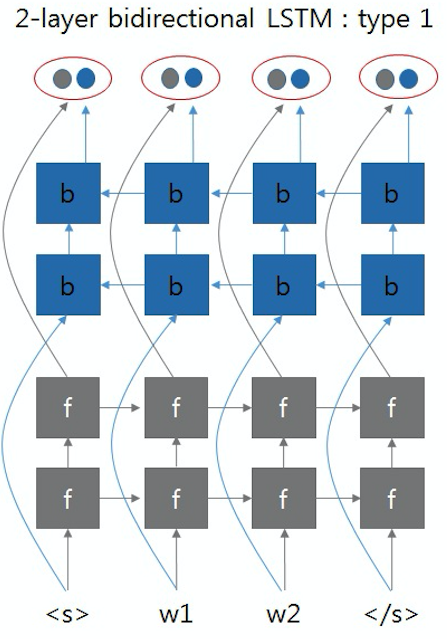

```python
from IPython.display import Image, display
display(Image(filename='bidirectional_rnn_arch.png', width=300))
```

```python
class RNNModel(nn.Module):
    def __init__(self, mode, input_size, hidden_size, num_layers, bias, output_size):
        super(RNNModel, self).__init__()
        self.mode = mode
        self.input_size = input_size
        self.hidden_size = hidden_size
        self.num_layers = num_layers
        self.bias = bias
        self.output_size = output_size

        self.rnn_cell_list = nn.ModuleList()

        if mode == 'LSTM':
            ########################################################################
            ## START OF YOUR CODE - Question 2a) Complete the missing code
            #
            #  Append the appropriate LSTM cells to rnn_cell_list
            ########################################################################

            self.rnn_cell_list.append(LSTMCell(self.input_size, self.hidden_size, self.bias))

            ########################################################################
            ## END OF YOUR CODE
            ########################################################################

        elif mode == 'GRU':

            ########################################################################
            ## START OF YOUR CODE - Question 2b) Complete the missing code
            #
            #  Append the appropriate GRU cells to rnn_cell_list
            ########################################################################

            self.rnn_cell_list.append(GRUCell(self.input_size, self.hidden_size, self.bias))

            ########################################################################
            ## END OF YOUR CODE
            ########################################################################

        elif mode == 'RNN_TANH':


            ########################################################################
            ## START OF YOUR CODE - Question 2c) Complete the missing code
            #
            #  Append the appropriate RNN cells to rnn_cell_list
            ########################################################################

            self.rnn_cell_list.append(BasicRNNCell(self.input_size, self.hidden_size, self.bias))

            ########################################################################
            ## END OF YOUR CODE
            ########################################################################



        elif mode == 'RNN_RELU':

            ########################################################################
            ## START OF YOUR CODE - Question 2d) Complete the missing code
            #
            #  Append the appropriate RNN cells to rnn_cell_list
            ########################################################################

            self.rnn_cell_list.append(BasicRNNCell(self.input_size, self.hidden_size, self.bias, nonlinearity="relu"))

            ########################################################################
            ## END OF YOUR CODE
            ########################################################################


        else:
            raise ValueError("Invalid RNN mode selected.")

        self.fc = nn.Linear(self.hidden_size, self.output_size)


    def forward(self, input, hx=None):

        outs = []
        h0 = [None] * self.num_layers if hx is None else list(hx)

        # In this forward pass we want to create our RNN from the rnn cells,
        # ..taking the hidden states from the final RNN layer and passing these
        # ..through our fully connected layer (fc).

        # The multi-layered RNN should be able to run when the mode is either
        # .. LSTM, GRU, RNN_TANH or RNN_RELU.

        ########################################################################
        ## START OF YOUR CODE - Question 2e) Complete the missing code
        #
        #  HINT: You may need a special case for LSTMs
        ########################################################################
        for index_seq in range(input.size(1)):
            for index_rnn, rnn_cell in enumerate(self.rnn_cell_list):
                # Changing the input value at each step

                if self.mode == 'LSTM':
                    # Treat the case when the value inside h0 are singleton and not tuples (None VS (None, None))
                    h_input = (None, None) if h0[index_rnn] is None else (h0[index_rnn][0], h0[index_rnn][1])
                    # First rnn layer
                    if index_rnn == 0:
                        cell_input = input[:, index_seq, :]
                    else:
                        cell_input = h0[index_rnn-1][0]
                    # Below we have hy = (hy, cy)
                    hy = rnn_cell(cell_input, None if h_input[0] is None else h_input)

                # For GRU, RNN_TANH, and RNN_RELU
                else:
                    h_input = h0[index_rnn]
                    if index_rnn == 0:
                        cell_input = input[:, index_seq, :]
                    else:
                        cell_input = h0[index_rnn-1]
                    # We only pass hy here
                    hy = rnn_cell(cell_input, h_input)

                h0[index_rnn] = hy

            if self.mode == 'LSTM':
                outs.append(hy[0])
            else:
                outs.append(hy)

        ########################################################################
        ## END OF YOUR CODE
        ########################################################################

        out = outs[-1].squeeze()

        out = self.fc(out)

        return out


class BidirRecurrentModel(nn.Module):
    def __init__(self, mode, input_size, hidden_size, num_layers, bias, output_size):
        super(BidirRecurrentModel, self).__init__()
        self.mode = mode
        self.input_size = input_size
        self.hidden_size = hidden_size
        self.num_layers = num_layers
        self.bias = bias
        self.output_size = output_size

        self.rnn_cell_list = nn.ModuleList()
        self.rnn_cell_list_rev = nn.ModuleList()

        ########################################################################
        ## START OF YOUR CODE - Question 2f) Complete the missing code
        #
        #  Create code for the following 'mode' values:
        # 'LSTM', 'GRU', 'RNN_TANH' and 'RNN_RELU'
        ########################################################################
        if mode == 'LSTM':
            self.rnn_cell_list.append(LSTMCell(self.input_size, self.hidden_size, self.bias))
            self.rnn_cell_list_rev.append(LSTMCell(self.input_size, self.hidden_size, self.bias))

        elif mode == 'GRU':
            self.rnn_cell_list.append(GRUCell(self.input_size, self.hidden_size, self.bias))
            self.rnn_cell_list_rev.append(GRUCell(self.input_size, self.hidden_size, self.bias))

        elif mode == 'RNN_TANH':
            self.rnn_cell_list.append(BasicRNNCell(self.input_size, self.hidden_size, self.bias))
            self.rnn_cell_list_rev.append(BasicRNNCell(self.input_size, self.hidden_size, self.bias))

        elif mode == 'RNN_RELU':
            self.rnn_cell_list.append(BasicRNNCell(self.input_size, self.hidden_size, self.bias, nonlinearity="relu"))
            self.rnn_cell_list_rev.append(BasicRNNCell(self.input_size, self.hidden_size, self.bias, nonlinearity="relu"))

        else:
            raise ValueError("Invalid RNN mode selected.")

        self.fc = nn.Linear(2*self.hidden_size, 3)

        ########################################################################
        ## END OF YOUR CODE
        ########################################################################


    def forward(self, input, hx=None):

        # In this forward pass we want to create our Bidirectional RNN from the rnn cells,
        # .. taking the hidden states from the final RNN layer with their reversed counterparts
        # .. before concatening these and running them through the fully connected layer (fc)

        # The multi-layered RNN should be able to run when the mode is either
        # .. LSTM, GRU, RNN_TANH or RNN_RELU.

        ########################################################################
        ## START OF YOUR CODE  - Question 2g) Complete the missing code
        ########################################################################
        outs = []
        outs_rev = []
        if self.mode == 'LSTM':
            h0 = [(None, None)] * self.num_layers if hx is None else list(hx)
            h0_rev = [(None, None)] * self.num_layers if hx is None else list(hx)
        else:
            h0 = [None] * self.num_layers if hx is None else list(hx)
            h0_rev = [None] * self.num_layers if hx is None else list(hx)

        for index_seq in range(input.size(1)):
            for index_rnn, rnn_cell in enumerate(self.rnn_cell_list):
                if self.mode == 'LSTM':
                    h_input = (h0[index_rnn][0], h0[index_rnn][1])
                    h_input_rev = (h0_rev[index_rnn][0], h0_rev[index_rnn][1])
                    # First rnn layer
                    if index_rnn == 0:
                        cell_input = input[:, index_seq, :]
                        cell_input_rev = input[:, -index_seq-1, :]
                    else:
                        cell_input = h0[index_rnn-1][0]
                        cell_input_rev = h0_rev[index_rnn-1][0]
                    # Below we have hy = (hy, cy)
                    hy = rnn_cell(cell_input, None if h_input[0] is None else h_input)
                    hy_rev = rnn_cell(cell_input_rev, None if h_input_rev[0] is None else h_input_rev)

                # For GRU, RNN_TANH, and RNN_RELU
                else:
                    h_input = h0[index_rnn]
                    h_input_rev = h0_rev[index_rnn]
                    if index_rnn == 0:
                        cell_input = input[:, index_seq, :]
                        cell_input_rev = input[:, -index_seq-1, :]
                    else:
                        cell_input = h0[index_rnn-1]
                        cell_input_rev = h0_rev[index_rnn-1]
                    # We only pass hy here
                    hy = rnn_cell(cell_input, h_input)
                    hy_rev = rnn_cell(cell_input_rev, h_input_rev)

                h0[index_rnn] = hy
                h0_rev[index_rnn] = hy_rev

            if self.mode == 'LSTM':
                outs.append(hy[0])
                outs_rev.append(hy_rev[0])
            else:
                outs.append(hy)
                outs_rev.append(hy_rev)

        ########################################################################
        ## END OF YOUR CODE
        ########################################################################

        out = outs[-1].squeeze()
        out_rev = outs_rev[0].squeeze()
        out = torch.cat((out, out_rev), 1)

        out = self.fc(out)
        return out
```

The code below trains a network based on your code above. This should work without error:

```python
seq_dim, input_dim = train_dataset[0][0].shape
output_dim = 3

hidden_dim = 64
layer_dim = 2
bias = True

### Change the code below to try running different models:
#model = RNNModel("GRU", input_dim, hidden_dim, layer_dim, bias, output_dim)
model = BidirRecurrentModel("GRU", input_dim, hidden_dim, layer_dim, bias, output_dim)

if torch.cuda.is_available():
    model.cuda()

criterion = nn.CrossEntropyLoss()

learning_rate = 0.001
optimizer = torch.optim.Adam(model.parameters(), lr=learning_rate)

loss_list = []
iter = 0
max_v_accuracy = 0
reported_t_accuracy = 0
max_t_accuracy = 0
for epoch in range(num_epochs):
    for i, (audio, labels) in enumerate(train_loader):
        if torch.cuda.is_available():
            audio = Variable(audio.view(-1, seq_dim, input_dim).cuda())
            labels = Variable(labels.cuda())
        else:
            audio = Variable(audio.view(-1, seq_dim, input_dim))
            labels = Variable(labels)

        optimizer.zero_grad()

        outputs = model(audio)

        loss = criterion(outputs, labels)

        if torch.cuda.is_available():
            loss.cuda()

        loss.backward()

        optimizer.step()

        loss_list.append(loss.item())
        iter += 1

        if iter % valid_every_n_steps == 0:
            correct = 0
            total = 0
            for audio, labels in valid_loader:
                if torch.cuda.is_available():
                    audio = Variable(audio.view(-1, seq_dim, input_dim).cuda())
                else:
                    audio = Variable(audio.view(-1, seq_dim, input_dim))

                outputs = model(audio)

                _, predicted = torch.max(outputs.data, 1)

                total += labels.size(0)

                if torch.cuda.is_available():
                    correct += (predicted.cpu() == labels.cpu()).sum()
                else:
                    correct += (predicted == labels).sum()

            v_accuracy = 100 * correct // total

            is_best = False
            if v_accuracy >= max_v_accuracy:
                max_v_accuracy = v_accuracy
                is_best = True

            if is_best:
                for audio, labels in test_loader:
                    if torch.cuda.is_available():
                        audio = Variable(audio.view(-1, seq_dim, input_dim).cuda())
                    else:
                        audio = Variable(audio.view(-1, seq_dim, input_dim))

                    outputs = model(audio)

                    _, predicted = torch.max(outputs.data, 1)

                    total += labels.size(0)

                    if torch.cuda.is_available():
                        correct += (predicted.cpu() == labels.cpu()).sum()
                    else:
                        correct += (predicted == labels).sum()

                t_accuracy = 100 * correct // total
                reported_t_accuracy = t_accuracy

            print('Epoch: {} Iteration: {}. Loss: {}. V-Accuracy: {}  T-Accuracy: {}'.format(epoch, iter, loss.item(), v_accuracy, reported_t_accuracy))
```

```
Epoch: 0 Iteration: 20. Loss: 1.069617748260498. V-Accuracy: 44  T-Accuracy: 43
Epoch: 0 Iteration: 40. Loss: 1.0150271654129028. V-Accuracy: 50  T-Accuracy: 50
Epoch: 0 Iteration: 60. Loss: 0.982654869556427. V-Accuracy: 68  T-Accuracy: 68
Epoch: 0 Iteration: 80. Loss: 0.9206091165542603. V-Accuracy: 68  T-Accuracy: 68
Epoch: 1 Iteration: 100. Loss: 0.8472647666931152. V-Accuracy: 79  T-Accuracy: 77
Epoch: 1 Iteration: 120. Loss: 0.8053025007247925. V-Accuracy: 81  T-Accuracy: 80
Epoch: 1 Iteration: 140. Loss: 0.7843500375747681. V-Accuracy: 80  T-Accuracy: 80
Epoch: 1 Iteration: 160. Loss: 0.7323675751686096. V-Accuracy: 84  T-Accuracy: 81
Epoch: 1 Iteration: 180. Loss: 0.677507221698761. V-Accuracy: 84  T-Accuracy: 81
Epoch: 2 Iteration: 200. Loss: 0.6084410548210144. V-Accuracy: 85  T-Accuracy: 83
Epoch: 2 Iteration: 220. Loss: 0.5943530797958374. V-Accuracy: 86  T-Accuracy: 84
Epoch: 2 Iteration: 240. Loss: 0.5259394645690918. V-Accuracy: 88  T-Accuracy: 86
Epoch: 2 Iteration: 260. Loss: 0.559492290019989. V-Accuracy: 88  T-Accuracy: 86
Epoch: 3 Iteration: 280. Loss: 0.4164126217365265. V-Accuracy: 88  T-Accuracy: 87
Epoch: 3 Iteration: 300. Loss: 0.4692420959472656. V-Accuracy: 89  T-Accuracy: 87
Epoch: 3 Iteration: 320. Loss: 0.4034811854362488. V-Accuracy: 90  T-Accuracy: 88
Epoch: 3 Iteration: 340. Loss: 0.39278557896614075. V-Accuracy: 88  T-Accuracy: 88
Epoch: 3 Iteration: 360. Loss: 0.32493698596954346. V-Accuracy: 90  T-Accuracy: 88
Epoch: 4 Iteration: 380. Loss: 0.3492995798587799. V-Accuracy: 91  T-Accuracy: 90
Epoch: 4 Iteration: 400. Loss: 0.25360357761383057. V-Accuracy: 91  T-Accuracy: 90
Epoch: 4 Iteration: 420. Loss: 0.35615861415863037. V-Accuracy: 92  T-Accuracy: 91
Epoch: 4 Iteration: 440. Loss: 0.32049599289894104. V-Accuracy: 92  T-Accuracy: 91
Epoch: 4 Iteration: 460. Loss: 0.27050355076789856. V-Accuracy: 92  T-Accuracy: 91
```

## Part 2: Theoretical questions

#### Theory question 1:

What is the *vanishing gradients problem* and why does it occur? Which activation functions are more or less impacted by this, and why?

#### Your answers:

Your answer here describing vanishing gradients problem:

- The vanishing gradient problem happends when the training is unstable and the gradient tends to be almost equal to zeros. Indeed it happends when the activation entries are too sparse and passed into activation functions that have derivatives equal to zero for this sparse entries. Then it doesn't have any impact on the backpropagationa computation and it is hard to converge properly.

Two examples of activation functions more impacted by vanishing gradients:

- Sigmoid and Tanh are both activation functions impacted by the vanishing gradient problem as they have derivatives that tends to zero for extreme input values. Let's get a closer a look with the example of Tanh. When the value of tanh(x) ≈ ±1, then we have tanh'(x) ≈ 0, i.e. the derivative is saturated and the gradient is vanished. This is the same idea for the sigmoid function.

Two examples of activation functions less impacted by vanishing gradients, why are they impacted less?

- ReLU suffers less from the vanishing gradient problem, as it only saturates in one direction (negative values). LeakyReLu is even less impacted by vanishing gradients as it does not saturates from any direction as the output value for negative entries is not exactly equal to zero but equal to a negative value close to zero.

#### Theory question 2:

Why do LSTMs help address the vanishing gradient problem compared to a vanilla RNN?

- The Long Short-Term Memory has indeed been proposed to address the vanishing gradient problem by introducing gates and memory cell states to control the error flow. In the meantime the vanilla RNN struggle to learn long term dependencies because the hidden state is constently being rewritten, while the LSTMs can cope with it thanks to the usage of forget gates. However, there is no guarantee that this term will not vanish (or even explode), but it tends to make the reduce its effect. For instance, if f is set to 1 at time t+1 until a certain time t+tau (remembers everything and maintains the cells state). It then prevents the gradient info at time t from vanishing (as ct+1 = <ft+1, ct> + ...). However, it should be stressed again that LSTMs do not completely solve the problem of vanishing gradient, but empirical evidences have shown that LSTMs are better at learning longer term dependencies in comparison to simple vanilla RNNs that don't use cell states and forget gates.

#### Theory question 3:

The plot below shows the training curves for three models A, B, and C, trained on the same dataset up to 100 epochs. The three models are a RNN, a LSTM and a GRU, not necessarily in that order.

- Which could plausibly be which? Why? Please explain your reasoning.

(In the cell below please set the values for A_model, B_model and C_model to be 'RNN', 'LSTM' or 'GRU'. This needs to be exact for the automatic marking.)

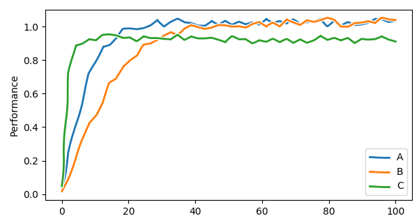

```python
from IPython.display import Image, display
display(Image(filename='Performance by epoch.png', width=550))
```

```python
# Answers below:

A_model = 'GRU'
B_model = 'LSTM'
C_model = 'RNN'

# Give your reasons below:
# As the GRU have only two gates, it has therefore fewer parameters than LSTM.
# Then intuitively, I would say that the GRU converges faster than LSTM but not better
# as they are both built to prevent from vanishing or exploding gradients. In the meantime RNNs
# have the worst performance as it is affected by these gradient problems but still have
# the faster convergence thanks to simplicity of its cells computations.
#
# To sum up I would say that A is GRU, B is LSTM and C is RNN.
```

#### Your answers:

As the GRU have only two gates, it has therefore fewer parameters than LSTM.Then intuitively, I would say that the GRU converges faster than LSTM but not betteras they are both built to prevent from vanishing or exploding gradients. In the meantime RNNshave the worst performance as it is affected by these gradient problems but still havethe faster convergence thanks to simplicity of its cells computations.

To sum up I would say that A is GRU, B is LSTM and C is RNN.

#### Theory question 4:

When might you choose to use each of the three different types of models?

#### Your answers:

Type of problem when best to use vanilla RNN:

- If we have short sequence that does not need to have long term dependencies then we can stick to vanilla RNN as it learns faster thanks to the simplicity of the cells.

Type of problem to use GRU:

- Both GRU and LSTM implements a mechanism to learn long-term dependencies. But if we have a normal dataset (in term of size) we can stick to GRU. Indeed it uses less training parameter (3 Weight matrices VS 4 Weight matrices for LSTMs) and therefore uses less memory and executes faster than LSTMs.

Type of problem to use LSTM:

- However if we have a really large dataset empirical evidences have proven that LSTM tends to be more accurate than GRU even though longer to train.